# Concord_spec_Tommy.With loops

```r
rm(list=ls())

require(stringr)
require(zoo)

source("concord_filter.R")
source("cospectra_plot3.R")
na.count<-function(x) sum(is.na(x))
```

```r
## change root.path as needed
root.path<-"C:\\Users\\Tommy\\flux\\Data-exploring\\02_Concord\\"
eddypro.path<-paste0(root.path,"01_Proccessed_Data\\Master_Eddy\\") ## this is where the EddyPro outputs located
plot.path<-paste0(root.path,"01_Proccessed_Data\\spectrum_plot\\") ## this is where the output plots located
```

```r
## use follows to specify the versions of EddyPro outputs
#cdata.proc.case<-"spectral_data"
cdata.proc.time<-"2020-04-17T161020"
cdata.proc.ext<-"_adv"
#20190614-1700_binned_cospectra_2020-04-17T161020_adv
```

```r
## handle full output file
# file name
cdata.file2<-paste0("master_eddy_pro_concord.csv")

#"C:\Users\Tommy\flux\Data-exploring\02_Concord\01_Proccessed_Data\Master_Eddy"
#"C:\Users\Tommy\flux\Data-exploring\02_Concord\01_Proccessed_Data\Master_Eddy\master_eddy_pro_concord.csv"
#"C:\Users\Tommy\flux\Data-exploring\02_Concord\01_Proccessed_Data\Master_Eddy\eddypro_binned_cospectra"
#"C:\Users\Tommy\flux\Data-exploring\02_Concord\01_Proccessed_Data\Master_Eddy\eddypro_full_cospectra"
#"C:\Users\Tommy\flux\Data-exploring\02_Concord\01_Proccessed_Data\Master_Eddy\spectrum_plot"
```

```r
## read in full output file
cdata<-read.csv(paste(eddypro.path,cdata.file2,sep=""),
                skip=3,
                header=F,
                na.strings="-9999",
                stringsAsFactors=F)
colnames(cdata)<-colnames(read.csv(paste(eddypro.path,cdata.file2,sep=""),
                                   skip=1,
                                   header=T,
                                   na.strings="NaN"))

cdata<-cdata[cdata$filename!="not_enough_data"&
               !is.na(cdata$used_records),]
```

# Defining the data I/O directory for the Master met_data

```r
path_met<-"C:\\Users\\Tommy\\flux\\Data-exploring\\02_Concord\\"
path.in_met<-paste(path_met,"01_Proccessed_Data",sep="")
path.out_met<-paste(path_met,"03_combined_data",sep="")
ver<-"met_data"
file.name<-paste("MET_data_master",sep="")
```

#read in Met_Data Master file, parse variable names and define N/As#

```r
met_data_master<-read.csv(paste(path.in_met,"\\",ver,"\\",file.name,".csv",sep=""),
                          header=F,
                          skip=4,
                          na.strings=c("NAN"),
                          stringsAsFactors = F)
colnames(met_data_master)<-colnames(
  read.csv(paste(path.in_met,"\\",ver,"\\",file.name,".csv",sep=""),
           header=T,
           skip= 1))

head(met_data_master)
```

|  | TIMESTAMP | RECORD | BattV_Avg | PTemp_C_Avg | AM25T_ref_Avg | TC_Avg.1. | TC_Avg.2. | TC_Avg.3. | TC_Avg.4. | TC_Avg.5. | TC_Avg.6. | TC_Avg.7. | TC_Avg.8. | TC_Avg.9. | TC_Avg.10. | TC_Avg.11. | TC_Avg.12. | TC_Avg.13. | TC_Avg.14. | TC_Avg.15. | TC_Avg.16. | TC_Avg.17. | TC_Avg.18. | TC_Avg.19. | TC_Avg.20. | TC_Avg.21. | TC_Avg.22. | TC_Avg.23. | TC_Avg.24. | … |
| --- | --- | --- | --- | --- | --- | --- | --- | --- | --- | --- | --- | --- | --- | --- | --- | --- | --- | --- | --- | --- | --- | --- | --- | --- | --- | --- | --- | --- | --- | --- |
| 1 | 6/25/2019 9:00 | 530 | 19.35 | 24.83 | NA | NA | NA | NA | NA | NA | NA | NA | NA | NA | NA | NA | NA | NA | NA | NA | NA | NA | NA | NA | NA | NA | NA | NA | NA | … |
| 2 | 6/25/2019 9:30 | 531 | 19.35 | 26.16 | NA | NA | NA | NA | NA | NA | NA | NA | NA | NA | NA | NA | NA | NA | NA | NA | NA | NA | NA | NA | NA | NA | NA | NA | NA | … |
| 3 | 6/25/2019 10:00 | 532 | 19.35 | 27.16 | NA | NA | NA | NA | NA | NA | NA | NA | NA | NA | NA | NA | NA | NA | NA | NA | NA | NA | NA | NA | NA | NA | NA | NA | NA | … |
| 4 | 6/25/2019 10:30 | 533 | 19.34 | 27.90 | NA | NA | NA | NA | NA | NA | NA | NA | NA | NA | NA | NA | NA | NA | NA | NA | NA | NA | NA | NA | NA | NA | NA | NA | NA | … |
| 5 | 6/25/2019 11:00 | 534 | 19.34 | 28.61 | NA | NA | NA | NA | NA | NA | NA | NA | NA | NA | NA | NA | NA | NA | NA | NA | NA | NA | NA | NA | NA | NA | NA | NA | NA | … |
| 6 | 6/25/2019 11:30 | 535 | 19.34 | 29.30 | NA | NA | NA | NA | NA | NA | NA | NA | NA | NA | NA | NA | NA | NA | NA | NA | NA | NA | NA | NA | NA | NA | NA | NA | NA | … |

```r
NA
```

# Parsing the time stamp converting it into a POSIXlt vector

**interpreting date and time into new timestamp column**

**Then taking that time stamp column and turning each time into a unique number (time.id) so I can join based on that. As it can be really tricky to join/merge based on time stamps alone**

**Or I could make sure both time stamps are characters and match them that way**

```r
cdata$TIMESTAMP<-strptime(paste(cdata$date,cdata$time,sep=" "),format="%m/%d/%Y %H:%M", tz = "GMT")

#cdata$TIMESTAMP=cdata$TIMESTAMP+1800 don't need to add 1800. already in endtime format

cdata$TIMESTAMP=cdata$TIMESTAMP #just rename it end. so that we know

cdata$time.id<-cdata$TIMESTAMP$year+1900+(cdata$TIMESTAMP$yday)/366+(cdata$TIMESTAMP$hour)/366/24+ (cdata$TIMESTAMP$min)/366/24/60

cdata$time.id[1:50]
```

```
 [1] 2019.450 2019.450 2019.450 2019.450 2019.450 2019.450 2019.450 2019.450 2019.451 2019.451 2019.451
[12] 2019.451 2019.451 2019.451 2019.451 2019.451 2019.451 2019.452 2019.452 2019.452 2019.452 2019.452
[23] 2019.452 2019.452 2019.452 2019.452 2019.452 2019.452 2019.452 2019.452 2019.452 2019.452 2019.452
[34] 2019.453 2019.453 2019.453 2019.453 2019.453 2019.453 2019.453 2019.453 2019.453 2019.453 2019.453
[45] 2019.453 2019.453 2019.454 2019.454 2019.454 2019.454
```

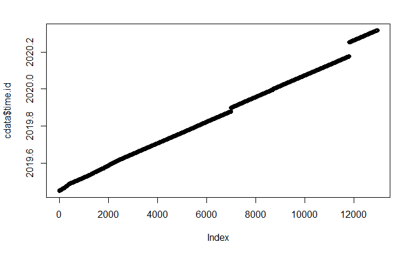

```r
plot(cdata$time.id)
```

```r
which(duplicated(cdata$time.id))
```

```
integer(0)
```

#Taking the met_data and turning the time stamp into posixt format#

```r
met_data_master$TIMESTAMP<-strptime(met_data_master$TIMESTAMP,
                                    format ="%m/%d/%Y %H:%M", tz = "GMT")

met_data_master$TIMESTAMP[1:20]
```

```
 [1] "2019-06-25 09:00:00 GMT" "2019-06-25 09:30:00 GMT" "2019-06-25 10:00:00 GMT"
 [4] "2019-06-25 10:30:00 GMT" "2019-06-25 11:00:00 GMT" "2019-06-25 11:30:00 GMT"
 [7] "2019-06-25 12:00:00 GMT" "2019-06-25 12:30:00 GMT" "2019-06-25 13:00:00 GMT"
[10] "2019-06-25 13:30:00 GMT" "2019-06-25 14:00:00 GMT" "2019-06-25 14:30:00 GMT"
[13] "2019-06-25 15:00:00 GMT" "2019-06-25 15:30:00 GMT" "2019-06-25 16:00:00 GMT"
[16] "2019-06-25 16:30:00 GMT" "2019-06-25 17:00:00 GMT" "2019-06-25 17:30:00 GMT"
[19] "2019-06-25 18:00:00 GMT" "2019-06-25 18:30:00 GMT"
```

#Making sure timestamp columns line up#. #need to do the half hour shift before merging. then after merge using full timestamp from MET file

```r
met_data_master$TIMESTAMP[1:10]
```

```
 [1] "2019-06-25 09:00:00 GMT" "2019-06-25 09:30:00 GMT" "2019-06-25 10:00:00 GMT"
 [4] "2019-06-25 10:30:00 GMT" "2019-06-25 11:00:00 GMT" "2019-06-25 11:30:00 GMT"
 [7] "2019-06-25 12:00:00 GMT" "2019-06-25 12:30:00 GMT" "2019-06-25 13:00:00 GMT"
[10] "2019-06-25 13:30:00 GMT"
```

```r
cdata$TIMESTAMP[1:10]
```

```
 [1] "2019-06-14 17:00:00 GMT" "2019-06-14 17:30:00 GMT" "2019-06-14 18:00:00 GMT"
 [4] "2019-06-14 18:30:00 GMT" "2019-06-14 19:30:00 GMT" "2019-06-14 20:00:00 GMT"
 [7] "2019-06-14 20:30:00 GMT" "2019-06-14 21:00:00 GMT" "2019-06-14 21:30:00 GMT"
[10] "2019-06-14 22:30:00 GMT"
```

```r
head(met_data_master)
```

|  | TIMESTAMP | RECORD | BattV_Avg | PTemp_C_Avg | AM25T_ref_Avg | TC_Avg.1. | TC_Avg.2. | TC_Avg.3. | TC_Avg.4. | TC_Avg.5. | TC_Avg.6. | TC_Avg.7. | TC_Avg.8. | TC_Avg.9. | TC_Avg.10. | TC_Avg.11. | TC_Avg.12. | TC_Avg.13. | TC_Avg.14. | TC_Avg.15. | TC_Avg.16. | TC_Avg.17. | TC_Avg.18. | TC_Avg.19. | TC_Avg.20. | TC_Avg.21. | TC_Avg.22. | TC_Avg.23. | TC_Avg.24. | … |
| --- | --- | --- | --- | --- | --- | --- | --- | --- | --- | --- | --- | --- | --- | --- | --- | --- | --- | --- | --- | --- | --- | --- | --- | --- | --- | --- | --- | --- | --- | --- |
| 1 |  | 530 | 19.35 | 24.83 | NA | NA | NA | NA | NA | NA | NA | NA | NA | NA | NA | NA | NA | NA | NA | NA | NA | NA | NA | NA | NA | NA | NA | NA | NA | … |
| 2 |  | 531 | 19.35 | 26.16 | NA | NA | NA | NA | NA | NA | NA | NA | NA | NA | NA | NA | NA | NA | NA | NA | NA | NA | NA | NA | NA | NA | NA | NA | NA | … |
| 3 |  | 532 | 19.35 | 27.16 | NA | NA | NA | NA | NA | NA | NA | NA | NA | NA | NA | NA | NA | NA | NA | NA | NA | NA | NA | NA | NA | NA | NA | NA | NA | … |
| 4 |  | 533 | 19.34 | 27.90 | NA | NA | NA | NA | NA | NA | NA | NA | NA | NA | NA | NA | NA | NA | NA | NA | NA | NA | NA | NA | NA | NA | NA | NA | NA | … |
| 5 |  | 534 | 19.34 | 28.61 | NA | NA | NA | NA | NA | NA | NA | NA | NA | NA | NA | NA | NA | NA | NA | NA | NA | NA | NA | NA | NA | NA | NA | NA | NA | … |
| 6 |  | 535 | 19.34 | 29.30 | NA | NA | NA | NA | NA | NA | NA | NA | NA | NA | NA | NA | NA | NA | NA | NA | NA | NA | NA | NA | NA | NA | NA | NA | NA | … |

#creating a time id for the MET Data so I I can join the MET and Eddy Pro Data#

```r
met_data_master$time.id <-met_data_master$TIMESTAMP$year+1900+(met_data_master$TIMESTAMP$yday)/366+(met_data_master$TIMESTAMP$hour)/366/24 + (met_data_master$TIMESTAMP$min)/366/24/60

met_data_master$time.id[1:20]
```

```
 [1] 2019.479 2019.479 2019.479 2019.479 2019.479 2019.479 2019.480 2019.480 2019.480 2019.480 2019.480
[12] 2019.480 2019.480 2019.480 2019.480 2019.480 2019.480 2019.480 2019.480 2019.480
```

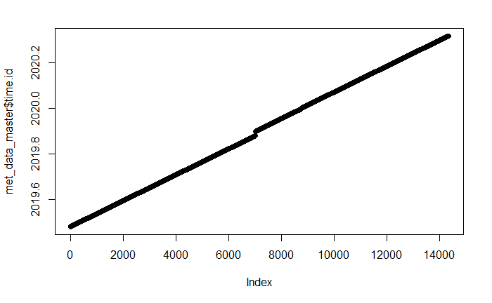

```r
plot(met_data_master$time.id)
```

```r
which(duplicated(met_data_master$time.id))
```

```
integer(0)
```

```r
head(met_data_master)
```

|  | TIMESTAMP | RECORD | BattV_Avg | PTemp_C_Avg | AM25T_ref_Avg | TC_Avg.1. | TC_Avg.2. | TC_Avg.3. | TC_Avg.4. | TC_Avg.5. | TC_Avg.6. | TC_Avg.7. | TC_Avg.8. | TC_Avg.9. | TC_Avg.10. | TC_Avg.11. | TC_Avg.12. | TC_Avg.13. | TC_Avg.14. | TC_Avg.15. | TC_Avg.16. | TC_Avg.17. | TC_Avg.18. | TC_Avg.19. | TC_Avg.20. | TC_Avg.21. | TC_Avg.22. | TC_Avg.23. | TC_Avg.24. | … |
| --- | --- | --- | --- | --- | --- | --- | --- | --- | --- | --- | --- | --- | --- | --- | --- | --- | --- | --- | --- | --- | --- | --- | --- | --- | --- | --- | --- | --- | --- | --- |
| 1 |  | 530 | 19.35 | 24.83 | NA | NA | NA | NA | NA | NA | NA | NA | NA | NA | NA | NA | NA | NA | NA | NA | NA | NA | NA | NA | NA | NA | NA | NA | NA | … |
| 2 |  | 531 | 19.35 | 26.16 | NA | NA | NA | NA | NA | NA | NA | NA | NA | NA | NA | NA | NA | NA | NA | NA | NA | NA | NA | NA | NA | NA | NA | NA | NA | … |
| 3 |  | 532 | 19.35 | 27.16 | NA | NA | NA | NA | NA | NA | NA | NA | NA | NA | NA | NA | NA | NA | NA | NA | NA | NA | NA | NA | NA | NA | NA | NA | NA | … |
| 4 |  | 533 | 19.34 | 27.90 | NA | NA | NA | NA | NA | NA | NA | NA | NA | NA | NA | NA | NA | NA | NA | NA | NA | NA | NA | NA | NA | NA | NA | NA | NA | … |
| 5 |  | 534 | 19.34 | 28.61 | NA | NA | NA | NA | NA | NA | NA | NA | NA | NA | NA | NA | NA | NA | NA | NA | NA | NA | NA | NA | NA | NA | NA | NA | NA | … |
| 6 |  | 535 | 19.34 | 29.30 | NA | NA | NA | NA | NA | NA | NA | NA | NA | NA | NA | NA | NA | NA | NA | NA | NA | NA | NA | NA | NA | NA | NA | NA | NA | … |

#Joining the Met_Data and Eddy Pro Data Sets#

#using time stamp from met file

**with merge**

```r
cdata<- merge(met_data_master, cdata[,-which(colnames(cdata)=="TIMESTAMP")], by = "time.id", all = TRUE, sort = TRUE) #all=true what ever appears in each file is show in the file data file. sort tries to sort each data frame by merging. in this case probably doesnot matter. timestamp



#cdata
```

```r
colnames(cdata)
```

```
  [1] "time.id"                       "TIMESTAMP"                     "RECORD"
  [4] "BattV_Avg"                     "PTemp_C_Avg"                   "AM25T_ref_Avg"
  [7] "TC_Avg.1."                     "TC_Avg.2."                     "TC_Avg.3."
 [10] "TC_Avg.4."                     "TC_Avg.5."                     "TC_Avg.6."
 [13] "TC_Avg.7."                     "TC_Avg.8."                     "TC_Avg.9."
 [16] "TC_Avg.10."                    "TC_Avg.11."                    "TC_Avg.12."
 [19] "TC_Avg.13."                    "TC_Avg.14."                    "TC_Avg.15."
 [22] "TC_Avg.16."                    "TC_Avg.17."                    "TC_Avg.18."
 [25] "TC_Avg.19."                    "TC_Avg.20."                    "TC_Avg.21."
 [28] "TC_Avg.22."                    "TC_Avg.23."                    "TC_Avg.24."
 [31] "TC_Avg.25."                    "AirT_Avg"                      "RH_Avg"
 [34] "AtmPressure_Avg"               "NR_mV_Avg"                     "NR_Wm2_Avg"
 [37] "PAR_in_mV_Avg"                 "PAR_in_uEm2_Avg"               "PAR_out_mV_Avg"
 [40] "PAR_out_uEm2_Avg"              "SHF_1_mV_Avg"                  "SHF_1_Wm2_Avg"
 [43] "SHF_2_mV_Avg"                  "SHF_2_Wm2_Avg"                 "WaterP_Avg"
```

[output cut: 43 more lines]

#Add back time stamp to the combo_master_ed_met#

```r
cdata$TIMESTAMP<-strptime(paste(cdata$date,cdata$time,sep=" "),format="%m/%d/%Y %H:%M", tz = "GMT")



cdata$TIMESTAMP<-strptime(cdata$TIMESTAMP,format="%Y-%m-%d %H:%M:%S", tz = "GMT")


#TIMESTAMP<-strptime(datetime$datetime,format="%m/%d/%Y %H:%M",tz="GMT")

cdata$TIMESTAMP[1:10]
```

```
 [1] "2019-06-14 17:00:00 GMT" "2019-06-14 17:30:00 GMT" "2019-06-14 18:00:00 GMT"
 [4] "2019-06-14 18:30:00 GMT" "2019-06-14 19:30:00 GMT" "2019-06-14 20:00:00 GMT"
 [7] "2019-06-14 20:30:00 GMT" "2019-06-14 21:00:00 GMT" "2019-06-14 21:30:00 GMT"
[10] "2019-06-14 22:30:00 GMT"
```

```r
cdata$TIMESTAMP[1:10]
```

```
 [1] "2019-06-14 17:00:00 GMT" "2019-06-14 17:30:00 GMT" "2019-06-14 18:00:00 GMT"
 [4] "2019-06-14 18:30:00 GMT" "2019-06-14 19:30:00 GMT" "2019-06-14 20:00:00 GMT"
 [7] "2019-06-14 20:30:00 GMT" "2019-06-14 21:00:00 GMT" "2019-06-14 21:30:00 GMT"
[10] "2019-06-14 22:30:00 GMT"
```

```r
#cdata$TIMESTAMP[10451:10453]

head(cdata)
```

|  | time.id | TIMESTAMP | RECORD | BattV_Avg | PTemp_C_Avg | AM25T_ref_Avg | TC_Avg.1. | TC_Avg.2. | TC_Avg.3. | TC_Avg.4. | TC_Avg.5. | TC_Avg.6. | TC_Avg.7. | TC_Avg.8. | TC_Avg.9. | TC_Avg.10. | TC_Avg.11. | TC_Avg.12. | TC_Avg.13. | TC_Avg.14. | TC_Avg.15. | TC_Avg.16. | TC_Avg.17. | TC_Avg.18. | TC_Avg.19. | TC_Avg.20. | TC_Avg.21. | TC_Avg.22. | TC_Avg.23. | … |
| --- | --- | --- | --- | --- | --- | --- | --- | --- | --- | --- | --- | --- | --- | --- | --- | --- | --- | --- | --- | --- | --- | --- | --- | --- | --- | --- | --- | --- | --- | --- |
| 1 | 2019.45 |  | NA | NA | NA | NA | NA | NA | NA | NA | NA | NA | NA | NA | NA | NA | NA | NA | NA | NA | NA | NA | NA | NA | NA | NA | NA | NA | NA | … |
| 2 | 2019.45 |  | NA | NA | NA | NA | NA | NA | NA | NA | NA | NA | NA | NA | NA | NA | NA | NA | NA | NA | NA | NA | NA | NA | NA | NA | NA | NA | NA | … |
| 3 | 2019.45 |  | NA | NA | NA | NA | NA | NA | NA | NA | NA | NA | NA | NA | NA | NA | NA | NA | NA | NA | NA | NA | NA | NA | NA | NA | NA | NA | NA | … |
| 4 | 2019.45 |  | NA | NA | NA | NA | NA | NA | NA | NA | NA | NA | NA | NA | NA | NA | NA | NA | NA | NA | NA | NA | NA | NA | NA | NA | NA | NA | NA | … |
| 5 | 2019.45 |  | NA | NA | NA | NA | NA | NA | NA | NA | NA | NA | NA | NA | NA | NA | NA | NA | NA | NA | NA | NA | NA | NA | NA | NA | NA | NA | NA | … |
| 6 | 2019.45 |  | NA | NA | NA | NA | NA | NA | NA | NA | NA | NA | NA | NA | NA | NA | NA | NA | NA | NA | NA | NA | NA | NA | NA | NA | NA | NA | NA | … |

```r
NA
NA
NA
```

#Creating a CSV File of my combined Master File!#

```r
write.csv(cdata,
   paste(eddypro.path,ver,"cdata",sep=""),
    quote = T,
  row.names = F)
```

```r
#############################################################
## Unit conversion & site-specified filtering

cdata<-concord_filter(data.in=cdata)

colnames(cdata)
```

```
  [1] "time.id"                       "TIMESTAMP"                     "RECORD"
  [4] "BattV_Avg"                     "PTemp_C_Avg"                   "AM25T_ref_Avg"
  [7] "TC_Avg.1."                     "TC_Avg.2."                     "TC_Avg.3."
 [10] "TC_Avg.4."                     "TC_Avg.5."                     "TC_Avg.6."
 [13] "TC_Avg.7."                     "TC_Avg.8."                     "TC_Avg.9."
 [16] "TC_Avg.10."                    "TC_Avg.11."                    "TC_Avg.12."
 [19] "TC_Avg.13."                    "TC_Avg.14."                    "TC_Avg.15."
 [22] "TC_Avg.16."                    "TC_Avg.17."                    "TC_Avg.18."
 [25] "TC_Avg.19."                    "TC_Avg.20."                    "TC_Avg.21."
 [28] "TC_Avg.22."                    "TC_Avg.23."                    "TC_Avg.24."
 [31] "TC_Avg.25."                    "AirT_Avg"                      "RH_Avg"
 [34] "AtmPressure_Avg"               "NR_mV_Avg"                     "NR_Wm2_Avg"
 [37] "PAR_in_mV_Avg"                 "PAR_in_uEm2_Avg"               "PAR_out_mV_Avg"
 [40] "PAR_out_uEm2_Avg"              "SHF_1_mV_Avg"                  "SHF_1_Wm2_Avg"
 [43] "SHF_2_mV_Avg"                  "SHF_2_Wm2_Avg"                 "WaterP_Avg"
```

[output cut: 44 more lines]

```r
#summary(cdata)
##############################################################
## Generic time series plot
target.plot.var<-c("co2_flux","LE","H","u.",
                   "co2_mixing_ratio","h2o_mixing_ratio",
                   "air_temperature_adj","RH",
                   "wind_speed","wind_dir","mean_value_RSSI_LI.7500",
                   "AirT_Avg", "Correct_NR",  "Correct_shf_1" , "Correct_shf_2", "VWC_Avg","Precip_mm_Tot" )
target.plot.var.title<-c(expression(FC~'('~mu~mol~m^{-2}~s^{-1}~')'),
                         expression(LE~'('~W~m^{-2}~')'),
                         expression(H~'('~W~m^{-2}~')'),
                         expression(u~star~'('~m~s^{-1}~')'),
                         expression(CO[2]~'('~ppm~')'),
                         expression(Water~vapor~'('~ppt~')'),
                         expression(Air~temperature~'('~degree~C~')'),
                         expression(Relative~humidity~'('~percentage~')'),
                         expression(Wind~speed~'('~m~s^{-1}~')'),
                         expression(Wind~direction~'('~degree~')'),
                         expression(LI7500~signal~strengh ~'('~'-'~')'),
                         expression(Air~temperature~MET~'('~degree~C~')'),
                         expression(Net~Radiation~'('~~W~m^{-2}~')'),
                         expression(Soil~Heatflux1~'('~~W~m^{-2}~')'),
                         expression(Soil~Heatflux2~'('~~W~m^{-2}~')'),
                         expression(Soil~VWC~'('~percentage~')'),
                         expression(Precipitation~'('~mm~')'))
# SHF2 not installed until november 18 and then Met Sensors went down until 12/5. so readings don't begin until 11/18/2020 at the earliest, most likely 12/5. Anything before 11/18 is noise!!!!!!

for(k1 in 1:length(target.plot.var)){
  png(paste0(plot.path,
             "Concord_",
             cdata$TIMESTAMP$year[1]+1900,"_",
            cdata$TIMESTAMP$yday[1]+1,"_",
             cdata$TIMESTAMP$year[nrow(cdata)]+1900,"_",
             cdata$TIMESTAMP$yday[nrow(cdata)]+1,"_",
             target.plot.var[k1],"_",
             Sys.Date(),".png"),
      width=5,
      height=3.5,
      units="in",
      res=200,
      pointsize = 12,
      bg = "white")

  par(oma=c(0.5,0.5,0.5,0.5),mar=c(4.5,4.5,0,0))
  plot(cdata$TIMESTAMP,
       cdata[,target.plot.var[k1]],
       xlab="TIMESTAMP",
       ylab=target.plot.var.title[k1],
       cex=0.5,col="grey",
       las=1,
       xaxs="i",yaxs="i"
  )
  loess.tmp<-loess(cdata[,target.plot.var[k1]]~c(1:nrow(cdata)),span=0.05)
  lines(cdata$TIMESTAMP[round(loess.tmp$x)],
        loess.tmp$fitted,
        lwd=1.5,col="red")

  dev.off()
}
```

work on (co)spectra data

```r
zL.cut.rng<-c(-5,-0.1,0.1,1) ## setting the 3 Z/L ranges for plotting
cspec.data.pre<-NULL

data.pre<-cdata

## work on file name of spectrum files
cspec.name.ls.parse<-paste(TIMESTAMP$year+1900,
                           sprintf("%02d",TIMESTAMP$mon+1),
                           sprintf("%02d",TIMESTAMP$mday),
                           "-",
                           sprintf("%02d",TIMESTAMP$hour),
                           sprintf("%02d",TIMESTAMP$min),
                           "_binned_cospectra",
                           sep="")
```

```r
## scan if spectrum files exist
cspec.name.ls<-rep(NA,length(cspec.name.ls.parse))
cspec.file.exist<-rep(FALSE,length(cspec.name.ls.parse))
cspec.file.ls<-list.files(paste0(eddypro.path,"eddypro_binned_cospectra\\"))
for(i in 1:length(cspec.file.exist)){
  cspec.name.ls[i]<-cspec.file.ls[which(grepl(cspec.name.ls.parse[i],
                                              cspec.file.ls))[1]]
  cspec.file.exist[i]<-ifelse(!is.na(cspec.name.ls[i]),
                              TRUE,
                              FALSE)
}

cspec.var.name<-c("n.f","f","fh.u","fSu","fSv","fSw","fSt","fSc","fSq","fSm","fSn",
                  "fCwu","fCwv","fCwt","fCwc","fCwq","fCwm","fCwn")
cspec.var.name.select<-c("n.f","f","fh.u","fSu","fSv","fSw","fSt","fSc","fSq",
                         "fCwu","fCwv","fCwt","fCwc","fCwq")
```

```r
## which spectrum variables to plot
target.cspec<-c("fSw","fSt","fSc","fSq",
                "fCwu","fCwt","fCwc","fCwq")
```

#for running just one month comment out 331

```r
### loop through the spetrum files, combine them into a single dataframe for plotting
month.id<-paste0(TIMESTAMP$year+1900,"-",sprintf("%02d",TIMESTAMP$mon+1))
month.id.ls<-list(names(table(month.id)),
                  as.vector(table(month.id)))
#can comment out 351 if you want to run just one month
#for(j1 in 1:length(month.id.ls[[1]])){
j1=1 #add just the month heere. comment out if wan to run full loop
cspec.data.pre<-data.frame()
target.mon<-month.id.ls[[1]][j1]
target.mon.loc<-which(month.id==target.mon)

print(paste0("######  ",target.mon,"  ######"))

for(i1 in 1:length(cspec.name.ls[target.mon.loc])){
  if(cspec.file.exist[target.mon.loc][i1]){




    ## read in each (co)spectra files
    cspec.data<-read.csv(paste(eddypro.path,
                               "eddypro_binned_cospectra\\",
                               cspec.name.ls[target.mon.loc][i1],sep=""),
                         skip=11,
                         header=T,
                         na.strings=c("-9999","-9999.0"))

    colnames(cspec.data)<-cspec.var.name

    ## combine spetrum data with basic state variables, e.g., WS, WD
    cspec.data.tmp<-data.frame(date=rep(data.pre$date[target.mon.loc][i1],nrow(cspec.data)),
                               time=rep(data.pre$time[target.mon.loc][i1],nrow(cspec.data)),
                               zL=rep(data.pre$X.z.d..L[target.mon.loc][i1],nrow(cspec.data)),
                               L=rep(data.pre$L[target.mon.loc][i1],nrow(cspec.data)),
                               WS=rep(data.pre$wind_speed[target.mon.loc][i1],nrow(cspec.data)),
                               WD=rep(data.pre$wind_dir[target.mon.loc][i1],nrow(cspec.data)),
                               cspec.data[,cspec.var.name.select])

    ### filter spetrum data based on corresponding variance/covariance

    if(is.na(data.pre$u.[target.mon.loc][i1])){
      cspec.data.tmp$fSu<-NA
      cspec.data.tmp$fCwu<-NA
      cspec.data.tmp$fSv<-NA
      cspec.data.tmp$fCwv<-NA
      cspec.data.tmp$fSw<-NA
    }
    if(is.na(data.pre$H[target.mon.loc][i1])){
      cspec.data.tmp$fSt<-NA
      cspec.data.tmp$fCwt<-NA
    }
    if(is.na(data.pre$co2_flux[target.mon.loc][i1])){
      cspec.data.tmp$fSc<-NA
      cspec.data.tmp$fCwc<-NA
    }
    if(is.na(data.pre$LE[target.mon.loc][i1])){
      cspec.data.tmp$fSq<-NA
      cspec.data.tmp$fCwq<-NA
    }
    cspec.data.pre<-rbind.data.frame(cspec.data.pre,cspec.data.tmp)
  }else{
    print(paste(cspec.name.ls.parse[target.mon.loc][i1],"has no spectrum files"))
  }
}


### output site-specific (co)spectra file (composite all records)
write.csv(cspec.data.pre,
          paste0(plot.path,
                 target.mon,
                 "_cospectra_compiled_",
                 Sys.Date(),".csv",
                 sep=""),
          row.names=F)

#### loop through the target.var, do spetrum plotting
for(m2 in 1:length(target.cspec)){

  cospectra_plot3(cspec.data.pre=cspec.data.pre,
                  target.var=target.cspec[m2],
                  case="Concord",
                  year=TIMESTAMP$year[target.mon.loc][1]+1900,
                  doy.i=TIMESTAMP$yday[target.mon.loc][1]+1,
                  doy.f=TIMESTAMP$yday[target.mon.loc][length(target.mon.loc)]+1,
                  output=T,
                  outDir=plot.path,
                  plot.loess=T,
                  postfix=paste0("_",Sys.Date()),
                  log.y.value=T,
                  zL.cut.rng=zL.cut.rng)

}
#} #comment out for just running one month. remove # if you want to run a full loop.
```